# Dynamic Reports with RMarkdown

Bern R Bootcamp

In this practical, I will analyse two datasets and show reproducible results in a dynamic document created in R Markdown. R Markdown is great because I can integrate `code` directly into my document, and easily use *italics* and **bold** using formatting tags.

# Fast Food Nutrition

### Overview

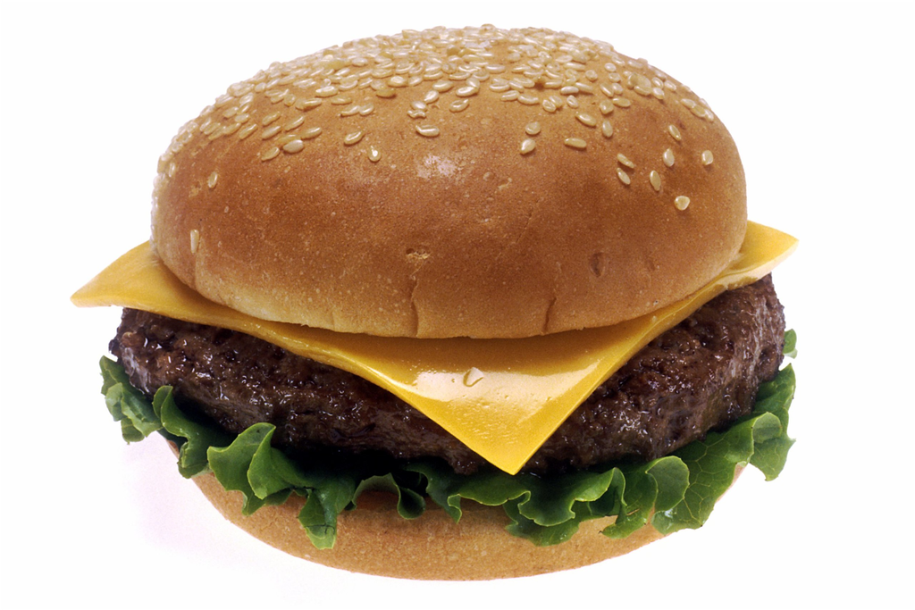

Source: Wikipedia

The `mcdonalds` data contains 24 pieces of information for 260 menu items. The data originally come from https://www.kaggle.com/mcdonalds/nutrition-facts.

### Data

Here is a table showing the first 6 columns in the data

|  | Category | Item | Serving Size | Calories | Calories from Fat | Total Fat |
| --- | --- | --- | --- | --- | --- | --- |
| 1 | Breakfast | Egg McMuffin | 4.8 oz (136 g) | 300 | 120 | 13 |
| 2 | Breakfast | Egg White Delight | 4.8 oz (135 g) | 250 | 70 | 8 |
| 3 | Breakfast | Sausage McMuffin | 3.9 oz (111 g) | 370 | 200 | 23 |
| 4 | Breakfast | Sausage McMuffin with Egg | 5.7 oz (161 g) | 450 | 250 | 28 |
| 5 | Breakfast | Sausage McMuffin with Egg Whites | 5.7 oz (161 g) | 400 | 210 | 23 |
| 6 | Breakfast | Steak &amp; Egg McMuffin | 6.5 oz (185 g) | 430 | 210 | 23 |
| 7 | Breakfast | Bacon, Egg &amp; Cheese Biscuit (Regular Biscuit) | 5.3 oz (150 g) | 460 | 230 | 26 |
| 8 | Breakfast | Bacon, Egg &amp; Cheese Biscuit (Large Biscuit) | 5.8 oz (164 g) | 520 | 270 | 30 |
| 9 | Breakfast | Bacon, Egg &amp; Cheese Biscuit with Egg Whites (Regular Biscuit) | 5.4 oz (153 g) | 410 | 180 | 20 |
| 10 | Breakfast | Bacon, Egg &amp; Cheese Biscuit with Egg Whites (Large Biscuit) | 5.9 oz (167 g) | 470 | 220 | 25 |

[output cut: 250 more lines]

### Calories Histogram

Across all items, the mean number of calories is 368.27 and the maximum is 1880. The following plot is a histogram showing the distribution of calories across all menu items

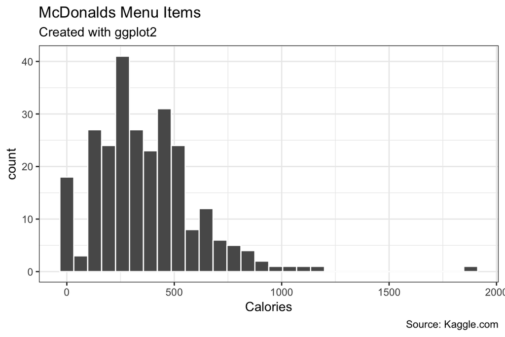

### Calories and Sodium Scatterplot

Is there a relationship between the number of calories and sodium in mcdonalds items? To answer this, let’s start by showing a scatterplot:

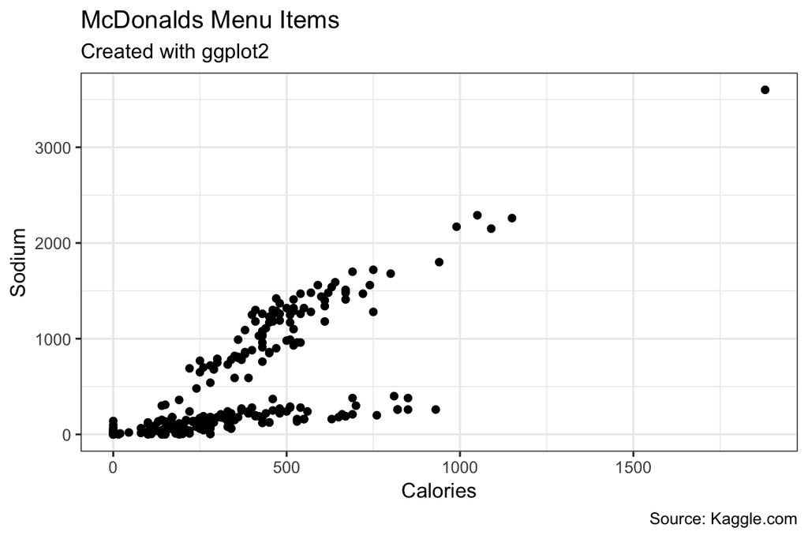

### Calories by Category

Which menu categories have the most calories? To answer this, we’ll start by creating a barplot showing the the mean calories for each menu category

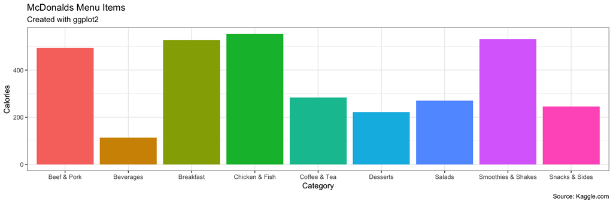

Here is a table showing summary statistics of each category

| Category | Min | Mean | Median | Max |
| --- | --- | --- | --- | --- |
| Beef & Pork | 240 | 494 | 500 | 750 |
| Beverages | 0 | 114 | 100 | 280 |
| Breakfast | 150 | 527 | 470 | 1150 |
| Chicken & Fish | 190 | 553 | 480 | 1880 |
| Coffee & Tea | 0 | 284 | 270 | 760 |
| Desserts | 45 | 222 | 250 | 340 |
| Salads | 140 | 270 | 255 | 450 |
| Smoothies & Shakes | 210 | 531 | 540 | 930 |
| Snacks & Sides | 15 | 246 | 260 | 510 |

### Regression

To see if there is a relationship between calories and sodium across menu items, I conducted a regression analysis using the `lm()` function in R, here are the main results:

| term | estimate | std.error | statistic | p.value |
| --- | --- | --- | --- | --- |
| (Intercept) | -134.2 | 46.1 | -2.9 | 0 |
| Calories | 1.7 | 0.1 | 16.3 | 0 |